# K-Means

# Tarea 4.

# Ejercicios

Librerias

```r
library('ggplot2')
library(GGally)
library(reshape)
library(tidyverse)
```

1. Desarrolle el Análisis del Problema.
2. Cargue el archivo Wholesale customers data.csv en una variable.
3. Desarolle el Entendimiento de los Datos.
4. Utilizando barplot cree un gráfico de los atributos del dataset, observe las correlaciones entre atributos.
5. Explique el gráfico.
6. Cree un modelo de agrupación K-Means.
7. Realice al menos 3 modelos cambiando los centroides.
8. Evaluación del modelo.
9. Desarolle al menos 5 conclusiones sobre los grupos realizados
- Ejemplo:
  - Las principales características de cada grupo son:
    - Grupo #1: (2do grupo más pequeño)
      - Principalmente observaciones de la región 3 y el canal 1.
      - Muy alto consumo de productos frescos.
      - Bajo consumo de leche.
      - Bajo consumo de comestibles.
      - Alto consumo de alimentos congelados.
      - Bajo consumo de detergentes.
      - Bajo consumo de delicassen.

## Análisis del Problema

A continuación se procede a analizar y utilizar el dataset **“Wholesale customers”** para generar agrupamiento de diversos productos al por mayor.

**Fuente del dataset**: https://archive.ics.uci.edu/ml/datasets/Wholesale+customers

**Descripción**: el dataset se refiere a clientes de distribuición mayorista en Portugal. Incluye el gasto anual en unidades monetarias en diversas categorías de productos. Incluye las siguientes variables:

- **Channel**: Canal de clientes - Horeca (Hotel / Restaurante / Café) o Canal minorista (Nominal).
- **Region**: Región de clientes - Lisbon, Oporto u Otro (Nominal).
- **Fresh**: gasto anual en productos frescos (Continuo).
- **Milk**: gasto anual en productos lácteos (Continuo).
- **Grocery**: gasto anual en productos comestibles (Continuo).
- **Frozen**: gasto anual en productos congelados (Continuo).
- **Detergents_paper**: gasto anual en detergentes y productos de papel (Continuo).
- **Delicatessen**: gasto anual en productos delicatessen (Continuo).

**Pregunta por contestar**: ¿Còmo se agrupan los datos de productos mayoristas según su gasto anual?

## Carga de Datos

```r
# Se carga el archivo .CSV en el dataset.
wholesale_data <- read.csv("Wholesale.csv")
```

## Entendimiento de los Datos

Primero demos un vistazo rápido a los datos dentro del dataset de **wholesale_data**. Además, podemos observar la cantidad de registros y variables.

```r
# Visualización de los primeros 6 elementos del dataset.
head(wholesale_data)
```

```
##   Channel Region Fresh Milk Grocery Frozen Detergents_Paper Delicassen
## 1       2      3 12669 9656    7561    214             2674       1338
## 2       2      3  7057 9810    9568   1762             3293       1776
## 3       2      3  6353 8808    7684   2405             3516       7844
## 4       1      3 13265 1196    4221   6404              507       1788
## 5       2      3 22615 5410    7198   3915             1777       5185
## 6       2      3  9413 8259    5126    666             1795       1451
```

```r
# ¿Cuántos datos hay en el dataset?
nrow(wholesale_data)
```

```
## [1] 440
```

```r
# ¿Cuáles son las variables con las que vamos a trabajar?
names(wholesale_data)
```

```
## [1] "Channel"          "Region"           "Fresh"
## [4] "Milk"             "Grocery"          "Frozen"
## [7] "Detergents_Paper" "Delicassen"
```

Al parecer tenemos 440 registros de productos al por mayor según el canal de clientes y la región. Además, se cuenta con 8 variables numéricas de las cuales 2 son categóricas (Channel y Region).

Vamos a revisar si los datos presentan valores NA o si existe alguna inconsistencia entre los valores que se presentan.

```r
# ¿Cómo se comportan los datos?
summary(wholesale_data)
```

```
##     Channel          Region          Fresh             Milk
##  Min.   :1.000   Min.   :1.000   Min.   :     3   Min.   :   55
##  1st Qu.:1.000   1st Qu.:2.000   1st Qu.:  3128   1st Qu.: 1533
##  Median :1.000   Median :3.000   Median :  8504   Median : 3627
##  Mean   :1.323   Mean   :2.543   Mean   : 12000   Mean   : 5796
##  3rd Qu.:2.000   3rd Qu.:3.000   3rd Qu.: 16934   3rd Qu.: 7190
##  Max.   :2.000   Max.   :3.000   Max.   :112151   Max.   :73498
##     Grocery          Frozen        Detergents_Paper    Delicassen
##  Min.   :    3   Min.   :   25.0   Min.   :    3.0   Min.   :    3.0
##  1st Qu.: 2153   1st Qu.:  742.2   1st Qu.:  256.8   1st Qu.:  408.2
##  Median : 4756   Median : 1526.0   Median :  816.5   Median :  965.5
##  Mean   : 7951   Mean   : 3071.9   Mean   : 2881.5   Mean   : 1524.9
##  3rd Qu.:10656   3rd Qu.: 3554.2   3rd Qu.: 3922.0   3rd Qu.: 1820.2
##  Max.   :92780   Max.   :60869.0   Max.   :40827.0   Max.   :47943.0
```

Al parecer no tenemos valores NA dentro de las variables. Además, no existen valores negativos lo cual es consistente con lo esperado al hablar al respecto de gasto anual (los valores deben ser igual o mayor a 0). A su vez se observa que la variable categórica de **Channel** posee 2 valores (Horeca o minorista) y la variable **Region** presenta 3 valores (Lisboa, Oporto y Otros) esto según lo esperado.

Vamos a observar las correlaciones entre atributos y las frecuencia de algunos valores:

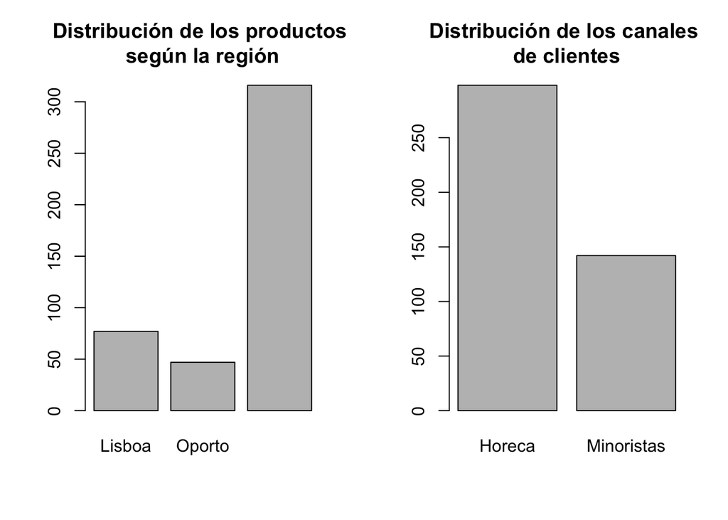

```r
# Vamos a visualizar ambos barplots uno al lado del otro.
par(mfcol = c(1, 2))

# ¿Cuál es la frecuencia de las regiones en el dataset?
with(wholesale_data, barplot(table(Region),
                             main = "Distribución de los productos \nsegún la región",
                             names.arg = c("Lisboa", "Oporto", "Otra Región")))

# ¿Cuál es la frecuencia de los canales de clientes en el dataset?
with(wholesale_data, barplot(table(Channel),
                             main = "Distribución de los canales \nde clientes",
                             names.arg = c("Horeca", "Minoristas")))
```

```r
# Volvemos a mostrar un gráfico por ventana.
par(mfcol = c(1, 1))
```

Como se observa en los gráficos anteriores, la moyor cantidad de datos se encuentran distribuidos entre “Otras Regiones” en el caso de la variable **Region** y “Horeca” (Hotel/Restaurante/Café) en el caso de **Channel**.

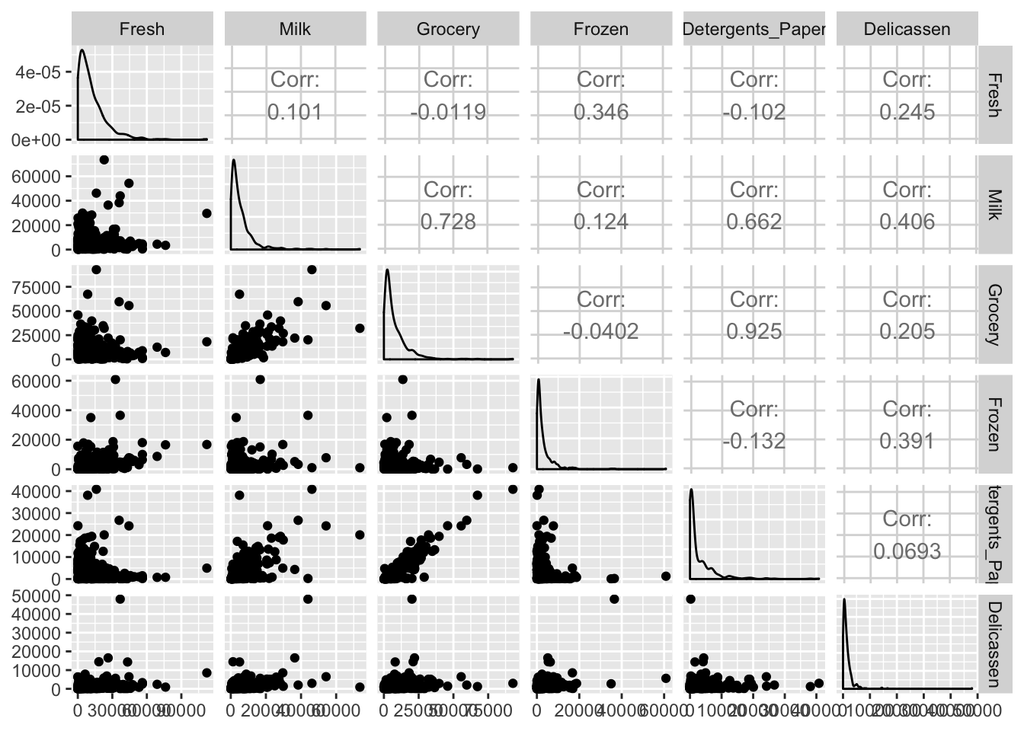

```r
# ¿Cómo se correlacionan las variables de gasto anual?
# Se omiten las variables Channel y Region al ser estas nominales categóricas.
ggpairs(wholesale_data[, 3:8])
```

Se observa una alta correlación positiva entre las variables **Grocery** y **Detergents_Paper** (0.925). Posterior a esta la siguiente correlación positiva significativa se encuentra entre **Grocery** y **Milk** (0.728). No se observan correlaciones negativas significativas. Todas las variables poseen una distribución sesgada a la derecha.

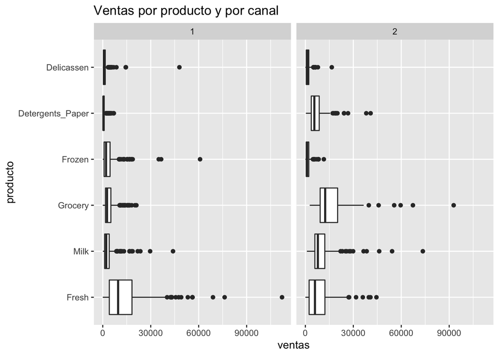

```r
# Explique el siguiente gráfico.
melted_wholesale_data <- melt(wholesale_data, id.vars = c("Region", "Channel"))
bxplt <- ggplot(data = melted_wholesale_data, aes(x= variable, y = value))
bxplt <- bxplt + geom_boxplot()
bxplt <- bxplt + facet_wrap(~Channel)
bxplt <- bxplt + coord_flip()
bxplt <- bxplt + labs(x = 'producto', y  = 'ventas')
bxplt <- bxplt + ggtitle('Ventas por producto y por canal')
bxplt
```

También observamos en el boxplot anterior como se comportan a nivel estadístico los valores de las ventas de los productos por canal. Se pueden observar una cantidad considerable de valores atípicos para cada uno de los tipo de productos según sus ventas. Además, se observa una mayor variabilidad de las ventas de los productos de tipo **Fresh** en el caso del canal “Horeca” (1) y de **Grocery**, **Milk** y **Fresh** en el caso del canal “Minorista” (2).

Este comportamiento de los datos quizás se pueda explicar mejor si lo vemos en lugar de filtrar “por canal” si lo mostramos “por región”.

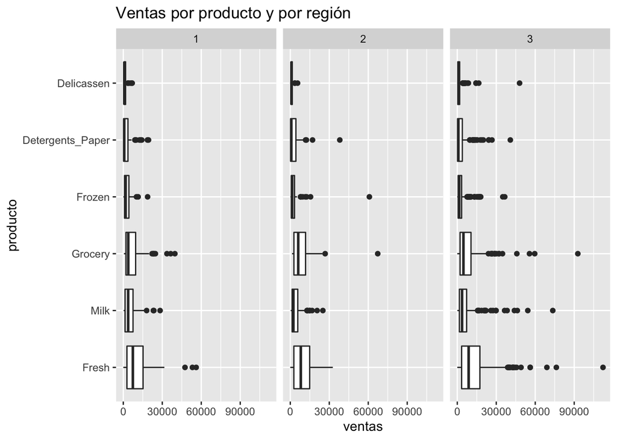

```r
bxplt <- ggplot(data = melted_wholesale_data, aes(x= variable, y = value))
bxplt <- bxplt + geom_boxplot()
bxplt <- bxplt + facet_wrap(~Region)
bxplt <- bxplt + coord_flip()
bxplt <- bxplt + labs(x = 'producto', y  = 'ventas')
bxplt <- bxplt + ggtitle('Ventas por producto y por región')
bxplt
```

Claramente se observa una variabilidad de los datos más similar entre las regiones y donde la variable con mayor variabilidad es **Fresh** seguido por **Grocery**. Finalmente cabe destacar que se observan menos valores atípicos en las regiones de “Lisboa” y “Oporto”, mientras que la mayor cantidad de valores atípicos se encuentran en la categoría de “Otra región”.

## Creación del Modelo

Para agrupar a los clientes con base al consumo, vamos a utilizar solo las variables **Fresh**, **Milk**, **Grocery**, **Frozen**, **Detergents_Paper** y **Delicatessen**. En este caso, vamos a intentar agrupar los clientes en 5 grupos diferentes.

```r
# Se crean 5 centroides utilizando k-means.
modelo_agrupacion_kmeans <- kmeans(wholesale_data[, c(3:8)], centers = 5)

# Utilizando el modelo se agrega una variable nueva llamada "cluster_5" al conjunto de datos.
wholesale_data$cluster_5 <- modelo_agrupacion_kmeans$cluster

# Se convierte la variable nueva a un factor.
wholesale_data$cluster_5 <- factor(wholesale_data$cluster_5)
```

Del mismo modo se probó agrupando en 2 grupos distintos.

```r
# Se crean 2 centroides utilizando k-means.
modelo_agrupacion_kmeans2 <- kmeans(wholesale_data[, c(3:8)], centers = 2)

# Utilizando el modelo se agrega una variable nueva llamada "cluster_2" al conjunto de datos.
wholesale_data$cluster_2 <- modelo_agrupacion_kmeans2$cluster

# Se convierte la variable nueva a un factor.
wholesale_data$cluster_2 <- factor(wholesale_data$cluster_2)
```

En 3 grupos distintos.

```r
# Se crean 3 centroides utilizando k-means.
modelo_agrupacion_kmeans3 <- kmeans(wholesale_data[, c(3:8)], centers = 3)

# Utilizando el modelo se agrega una variable nueva llamada "cluster_3" al conjunto de datos.
wholesale_data$cluster_3 <- modelo_agrupacion_kmeans3$cluster

# Se convierte la variable nueva a un factor.
wholesale_data$cluster_3 <- factor(wholesale_data$cluster_3)
```

Y en 6 grupos distintos.

```r
# Se crean 6 centroides utilizando k-means.
modelo_agrupacion_kmeans4 <- kmeans(wholesale_data[, c(3:8)], centers = 6)

# Utilizando el modelo se agrega una variable nueva llamada "cluster_6" al conjunto de datos.
wholesale_data$cluster_6 <- modelo_agrupacion_kmeans4$cluster

# Se convierte la variable nueva a un factor.
wholesale_data$cluster_6 <- factor(wholesale_data$cluster_6)
```

## Evaluación del Modelo

A continuación vamos a observar como se distribuyeron los datos según los 5 grupos generados en el primer k-means que se aplicó a los datos.

```r
# Se observan los datos distribuidos según la región.
by(wholesale_data$Region, wholesale_data$cluster_5, table)
```

```
## wholesale_data$cluster_5: 1
##
##  1  2  3
## 18 11 75
## --------------------------------------------------------
## wholesale_data$cluster_5: 2
##
##  1  2  3
##  3  1 19
## --------------------------------------------------------
## wholesale_data$cluster_5: 3
##
## 1 2 3
## 1 1 8
## --------------------------------------------------------
## wholesale_data$cluster_5: 4
##
##   1   2   3
##  41  23 159
## --------------------------------------------------------
## wholesale_data$cluster_5: 5
##
##  1  2  3
## 14 11 55
```

```r
# Se observan los datos distribuidos según el canal del cliente.
by(wholesale_data$Channel, wholesale_data$cluster_5, table)
```

```
## wholesale_data$cluster_5: 1
##
##  1  2
## 83 21
## --------------------------------------------------------
## wholesale_data$cluster_5: 2
##
##  1  2
## 21  2
## --------------------------------------------------------
## wholesale_data$cluster_5: 3
##
## 1 2
## 1 9
## --------------------------------------------------------
## wholesale_data$cluster_5: 4
##
##   1   2
## 186  37
## --------------------------------------------------------
## wholesale_data$cluster_5: 5
##
##  1  2
##  7 73
```

```r
# Se observa el gasto total en la categoría de productos del tipo "Fresh" en cada cluster.
by(wholesale_data$Fresh, wholesale_data$cluster_5, sum)
```

```
## wholesale_data$cluster_5: 1
## [1] 2204806
## --------------------------------------------------------
## wholesale_data$cluster_5: 2
## [1] 1133810
## --------------------------------------------------------
## wholesale_data$cluster_5: 3
## [1] 212637
## --------------------------------------------------------
## wholesale_data$cluster_5: 4
## [1] 1349777
## --------------------------------------------------------
## wholesale_data$cluster_5: 5
## [1] 379101
```

```r
# Se observa el gasto total en la categoría de productos del tipo "Milk" en cada cluster.
by(wholesale_data$Milk, wholesale_data$cluster_5, sum)
```

```
## wholesale_data$cluster_5: 1
## [1] 404188
## --------------------------------------------------------
## wholesale_data$cluster_5: 2
## [1] 114627
## --------------------------------------------------------
## wholesale_data$cluster_5: 3
## [1] 374433
## --------------------------------------------------------
## wholesale_data$cluster_5: 4
## [1] 728388
## --------------------------------------------------------
## wholesale_data$cluster_5: 5
## [1] 928721
```

```r
# Se observa el gasto total en la categoría de productos del tipo "Grocery" en cada cluster.
by(wholesale_data$Grocery, wholesale_data$cluster_5, sum)
```

```
## wholesale_data$cluster_5: 1
## [1] 534449
## --------------------------------------------------------
## wholesale_data$cluster_5: 2
## [1] 128577
## --------------------------------------------------------
## wholesale_data$cluster_5: 3
## [1] 467106
## --------------------------------------------------------
## wholesale_data$cluster_5: 4
## [1] 912528
## --------------------------------------------------------
## wholesale_data$cluster_5: 5
## [1] 1455902
```

```r
# Se observa el gasto total en la categoría de productos del tipo "Frozen" en cada cluster.
by(wholesale_data$Frozen, wholesale_data$cluster_5, sum)
```

```
## wholesale_data$cluster_5: 1
## [1] 428465
## --------------------------------------------------------
## wholesale_data$cluster_5: 2
## [1] 190573
## --------------------------------------------------------
## wholesale_data$cluster_5: 3
## [1] 62872
## --------------------------------------------------------
## wholesale_data$cluster_5: 4
## [1] 548509
## --------------------------------------------------------
## wholesale_data$cluster_5: 5
## [1] 121231
```

```r
# Se observa el gasto total en la categoría de productos del tipo "Detergent_Paper" en cada cluster.
by(wholesale_data$Detergents_Paper, wholesale_data$cluster_5, sum)
```

```
## wholesale_data$cluster_5: 1
## [1] 117678
## --------------------------------------------------------
## wholesale_data$cluster_5: 2
## [1] 22132
## --------------------------------------------------------
## wholesale_data$cluster_5: 3
## [1] 216994
## --------------------------------------------------------
## wholesale_data$cluster_5: 4
## [1] 270751
## --------------------------------------------------------
## wholesale_data$cluster_5: 5
## [1] 640302
```

```r
# Se observa el gasto total en la categoría de productos del tipo "Delicatessen" en cada cluster.
by(wholesale_data$Delicassen, wholesale_data$cluster_5, sum)
```

```
## wholesale_data$cluster_5: 1
## [1] 175795
## --------------------------------------------------------
## wholesale_data$cluster_5: 2
## [1] 58505
## --------------------------------------------------------
## wholesale_data$cluster_5: 3
## [1] 87433
## --------------------------------------------------------
## wholesale_data$cluster_5: 4
## [1] 220906
## --------------------------------------------------------
## wholesale_data$cluster_5: 5
## [1] 128304
```